# Visualizing Text and Distributions

Dhrishya Menon

2022-06-23

# Data Visualization Project 03

In this exercise you will explore methods to visualize text data and practice how to recreate charts that show the distributions of a continuous variable.

```r
#install.packages("viridis")
library(viridis)
#install.packages("ggridges")
library(ggridges)

library(forcats)
library(viridisLite)
library(lubridate)
```

## Part 1: Density Plots

Using the dataset obtained from FSU’s [Florida Climate Center](https://climatecenter.fsu.edu/climate-data-access-tools/downloadable-data), for a station at Tampa International Airport (TPA) from 2016 to 2017, attempt to recreate the charts shown below

```r
library(tidyverse)
weather_tpa <- read_csv("https://github.com/reisanar/datasets/raw/master/tpa_weather_16_17.csv")
# random sample
sample_n(weather_tpa, 4)
```

```
## # A tibble: 4 × 6
##    year month   day precipitation max_temp min_temp
##   <dbl> <dbl> <dbl>         <dbl>    <dbl>    <dbl>
## 1  2016     6    23          0          91       79
## 2  2016    10     1          0.02       89       74
## 3  2016     1    28          1.03       67       59
## 4  2016    10    20          0          88       68
```

See https://www.reisanar.com/slides/relationships-models#10 for a reminder on how to use this dataset with the `lubridate` package for dates and times.

1. Recreate the plot below:

```r
weather_tpa$month <- sapply(weather_tpa$month,as.factor)


weather_tpa$month <- factor(weather_tpa$month,
levels = c(1,2,3,4,5,6,7,8,9,10,11,12),
labels = c("January","February","March","April","May","June","July","August","September","October","November","December"))
```

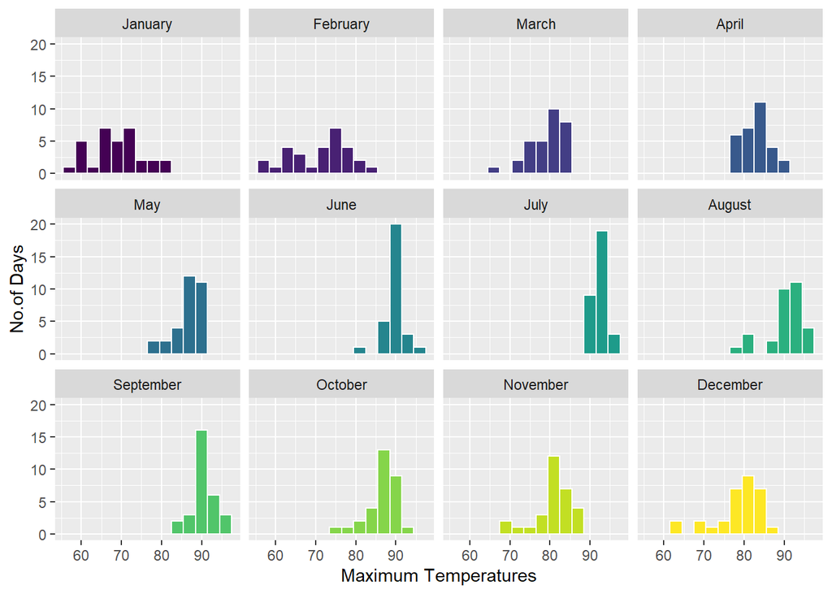

```r
ggplot(data = weather_tpa, aes(x = max_temp, fill=month)) +
  geom_histogram(binwidth = 3, color="white") +
  facet_wrap(~month) +
  labs(x = "Maximum Temperatures", y = "No.of Days") +
  scale_fill_viridis_d() +
  theme (legend.position = "none")
```

Hint: the option `binwidth = 3` was used with the `geom_histogram()` function.

2. Recreate the plot below:

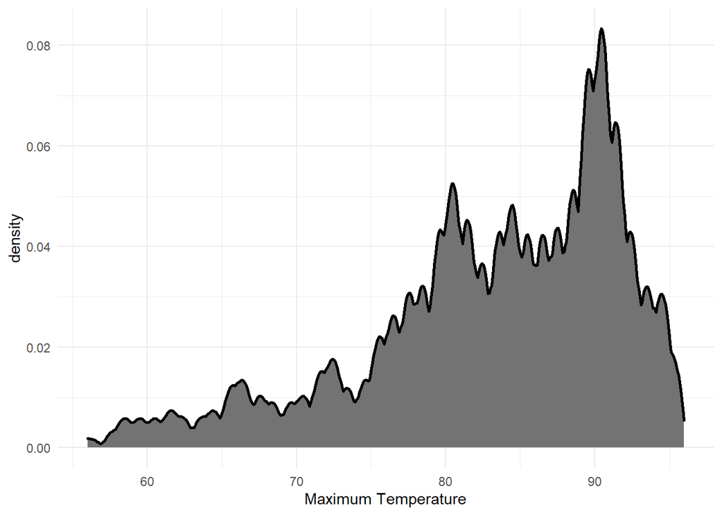

   Hint: check the `kernel` parameter of the `geom_density()` function, and use `bw = 0.5`.
3. Recreate the chart below:

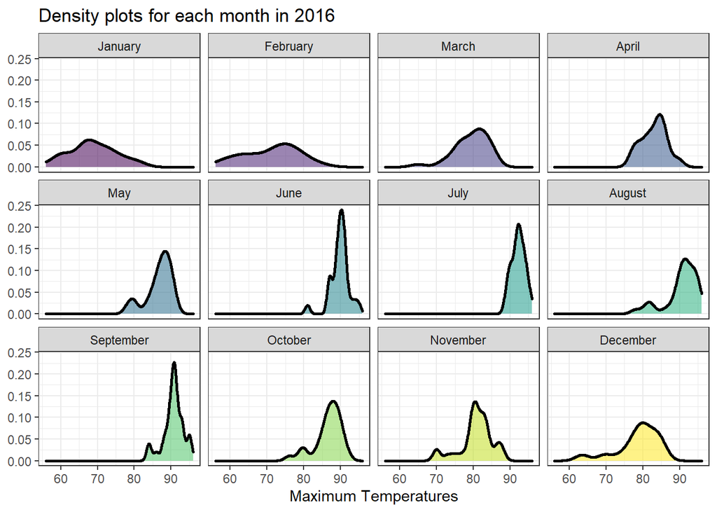

   Hint: default options for `geom_density()` were used.
4. Recreate the chart below:

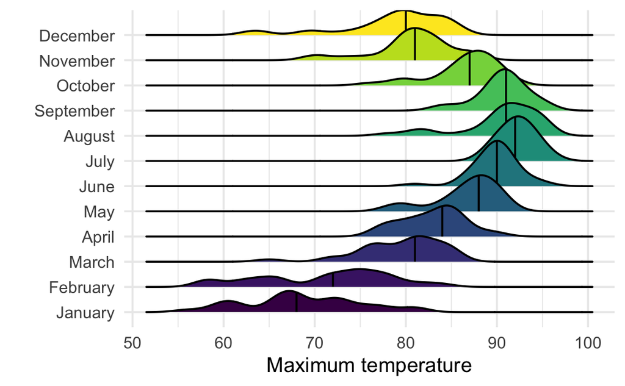

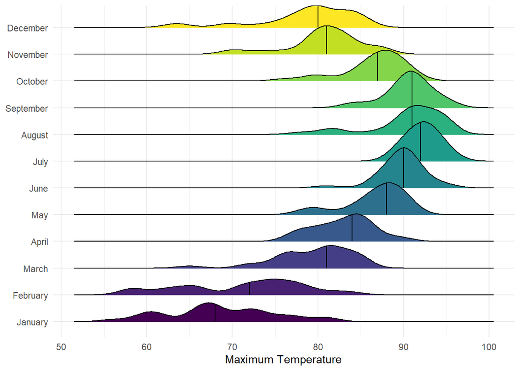

5. Recreate the plot below:

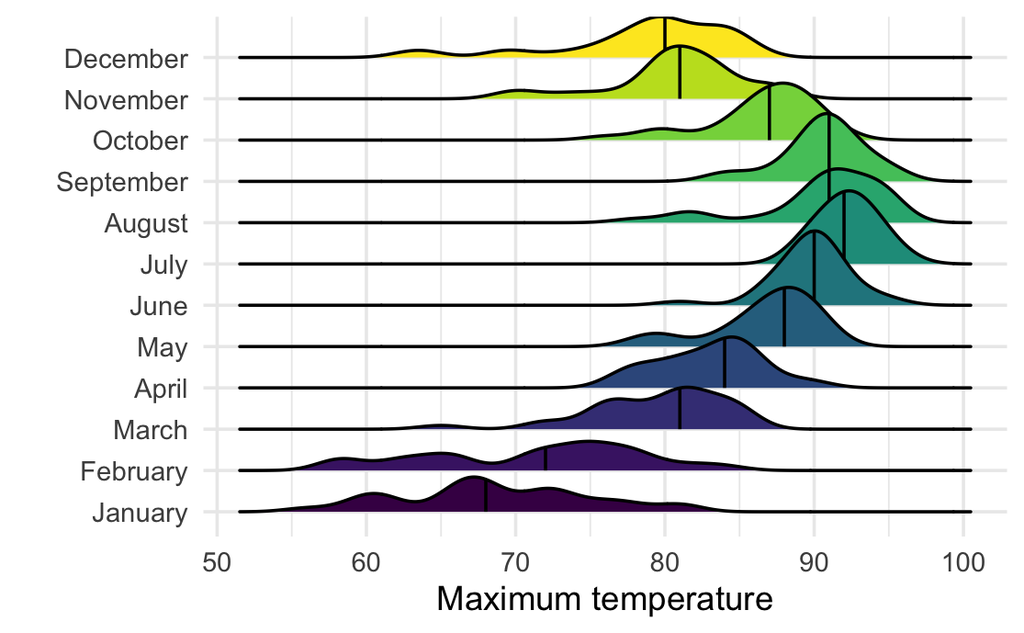

[figure not shown]

Hint: use the`ggridges` package, and the `geom_density_ridges()` function paying close attention to the `quantile_lines` and `quantiles` parameters. (f) Recreate the chart below:

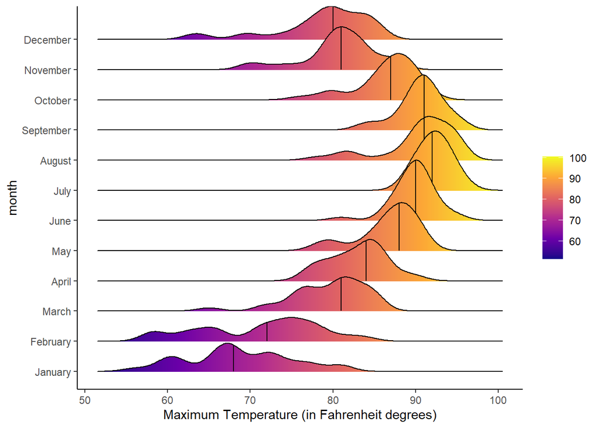

Hint: this uses the `plasma` option (color scale) for the *viridis* palette.

## Part 2: Visualizing Text Data

Review the set of slides (and additional resources linked in it) for visualizing text data: https://www.reisanar.com/slides/text-viz#1

Choose any dataset with text data, and create at least one visualization with it. For example, you can create a frequency count of most used bigrams, a sentiment analysis of the text data, a network visualization of terms commonly used together, and/or a visualization of a topic modeling approach to the problem of identifying words/documents associated to different topics in the text data you decide to use. Make sure to include a copy of the dataset in the `data/` folder, and reference your sources if different from the ones listed below: - [Billboard Top 100 Lyrics](https://github.com/reisanar/datasets/blob/master/BB_top100_2015.csv) - [RateMyProfessors comments](https://github.com/reisanar/datasets/blob/master/rmp_wit_comments.csv) - [FL Poly News 2020](https://github.com/reisanar/datasets/blob/master/poly_news_FL20.csv) - [FL Poly News 2019](https://github.com/reisanar/datasets/blob/master/poly_news_FL19.csv) (to get the “raw” data from any of the links listed above, simply click on the `raw` button of the GitHub page and copy the URL to be able to read it in your computer using the `read_csv()` function)

```r
#install.packages("tidytext")
library(tidytext)
#install.packages("textdata")
library(textdata)
```

```r
comments_data <- read_csv("https://raw.githubusercontent.com/reisanar/datasets/master/rmp_wit_comments.csv")
head(comments_data, 6)
```

```
## # A tibble: 6 × 2
##   course   comments
##   <chr>    <chr>
## 1 MATH1900 He is very enthusiastic to help students. His course content is orga…
## 2 MATH250  Great professor, really wants his students to pass. Puts all his not…
## 3 MATH2860 Lectures are clear and pretty easy to follow. He is always open to e…
## 4 MATH2860 He is a great professor. He mixes humor into all of his lectures, an…
## 5 MATH2025 i found him to be a good professor he keeps the class entertained an…
## 6 MATH2025 He is a great professor. I would take him again in a heartbeat. His …
```

```r
comments_data_words <- comments_data %>%
  unnest_tokens(word, comments) %>%
  mutate(
    course = str_trunc(course,
                     width = 15)) %>%
  select(word, course) %>%
  head()
```

```r
#install.packages("stopwords")
library(stopwords)

stopwords::stopwords(language = "english") %>%
  sample(10)
```

```
##  [1] "they"   "any"    "most"   "where"  "me"     "you're" "why"    "at"
##  [9] "i"      "their"
```